# Explore and work with NEON biodiversity data from aquatic ecosystems

## Learning Objectives

After completing this tutorial you will be able to:

- Download NEON macroinvertebrate data.
- Organize those data into long and wide tables.
- Calculate alpha, beta, and gamma diversity following Jost (2007).

## Things You’ll Need To Complete This Tutorial

### R Programming Language

You will need a current version of R to complete this tutorial. We also recommend the RStudio IDE to work with R.

### R Packages to Install

Prior to starting the tutorial ensure that the following packages are installed.

- **tidyverse:** `install.packages("tidyverse")`
- **neonUtilities:** `install.packages("neonUtilities")`
- **vegan:** `install.packages("vegan")`

[More on Packages in R](https://www.neonscience.org/packages-in-r) – Adapted from Software Carpentry.

## Introduction

Biodiversity is a popular topic within ecology, but quantifying and describing biodiversity precisely can be elusive. In this tutorial, we will describe many of the aspects of biodiversity using NEON’s [Macroinvertebrate Collection data](https://data.neonscience.org/data-products/DP1.20120.001).

This tutorial was prepared for the [Society for Freshwater Science 2021 NEON Aquatic Biodiversity Workshop](https://freshwater-science.org/sfs-summer-science).

## Load Libraries and Prepare Workspace

First, we will load all necessary libraries into our R environment. If you have not already installed these libraries, please see the ‘R Packages to Install’ section above.

There are also two optional sections in this code chunk: clearing your environment, and loading your NEON API token. Clearing out your environment will erase *all* of the variables and data that are currently loaded in your R session. This is a good practice for many reasons, but only do this if you are completely sure that you won’t be losing any important information! Secondly, your NEON API token will allow you increased download speeds, and helps NEON **anonymously** track data usage statistics, which helps us optimize our data delivery platforms, and informs our monthly and annual reporting to our funding agency, the National Science Foundation. Please consider signing up for a NEON data user account, and using your token [as described in this tutorial here](https://www.neonscience.org/neon-api-tokens-tutorial).

```r
# clean out workspace

#rm(list = ls()) # OPTIONAL - clear out your environment
#gc()            # Uncomment these lines if desired

# load libraries
library(tidyverse)
library(neonUtilities)
library(vegan)
# source .r file with my NEON_TOKEN
# source("my_neon_token.R") # OPTIONAL - load NEON token
# See: https://www.neonscience.org/neon-api-tokens-tutorial
```

## Download NEON Macroinvertebrate Data

Now that the workspace is prepared, we will download NEON macroinvertebrate data using the neonUtilities function `loadByProduct()`.

```r
# Macroinvert dpid
my_dpid <- 'DP1.20120.001'

# list of sites
my_site_list <- c('ARIK', 'POSE', 'MAYF')

# get all tables for these sites from the API -- takes < 1 minute
all_tabs_inv <- neonUtilities::loadByProduct(
  dpID = my_dpid,
  site = my_site_list,
  #token = NEON_TOKEN, #Uncomment to use your token
  check.size = F)
```

## Macroinvertebrate Data Munging

Now that we have the data downloaded, we will need to do some ‘data munging’ to reorganize our data into a more useful format for this analysis. First, let’s take a look at some of the tables that were generated by `loadByProduct()`:

```r
# what tables do you get with macroinvertebrate
# data product
names(all_tabs_inv)
```

```
## [1] "categoricalCodes_20120" "inv_fieldData"          "inv_persample"
## [4] "inv_taxonomyProcessed"  "readme_20120"           "validation_20120"
## [7] "variables_20120"
```

```r
# extract items from list and put in R env.
all_tabs_inv %>% list2env(.GlobalEnv)
```

```
## <environment: R_GlobalEnv>
```

```r
# readme has the same informaiton as what you
# will find on the landing page on the data portal

# The variables file describes each field in
# the returned data tables
View(variables_20120)

# The validation file provides the rules that
# constrain data upon ingest into the NEON database:
View(validation_20120)

# the categoricalCodes file provides controlled
# lists used in the data
View(categoricalCodes_20120)
```

Next, we will perform several operations in a row to re-organize our data. Each step is described by a code comment.

```r
# known problem with dupes published in the inv_fieldData table as of 2021-02-18
# this anticipated to be fixed in data release next year (Jan 2022)
# use sampleID as primary key, keep the first uid associated with any sampleID that has multiple uids
de_duped_uids <- inv_fieldData %>%
  group_by(sampleID) %>%
  summarise(n_recs = length(uid),
                   n_unique_uids = length(unique(uid)),
                   uid_to_keep = dplyr::first(uid))

# filter data using de-duped uids
inv_fieldData <- inv_fieldData %>%
  dplyr::filter(uid %in% de_duped_uids$uid_to_keep)




# extract year from date, add it as a new column
inv_fieldData <- inv_fieldData %>%
  mutate(
    year = collectDate %>%
      lubridate::as_date() %>%
      lubridate::year())




# extract location data into a separate table
table_location <- inv_fieldData %>%

  # keep only the columns listed below
  select(siteID,
         domainID,
         namedLocation,
         decimalLatitude,
         decimalLongitude,
         elevation) %>%

  # keep rows with unique combinations of values,
  # i.e., no duplicate records
  distinct()




# create a taxon table, which describes each
# taxonID that appears in the data set
# start with inv_taxonomyProcessed
table_taxon <- inv_taxonomyProcessed %>%

  # keep only the coluns listed below
  select(acceptedTaxonID, taxonRank, scientificName,
         order, family, genus,
         identificationQualifier,
         identificationReferences) %>%

  # remove rows with duplicate information
  distinct()



# taxon table information for all taxa in
# our database can be downloaded here:
# takes 1-2 minutes
# full_taxon_table_from_api <- neonUtilities::getTaxonTable("MACROINVERTEBRATE", token = NEON_TOKEN)




# Make the observation table.
# start with inv_taxonomyProcessed

# check for repeated taxa within a sampleID that need to be added together
inv_taxonomyProcessed_summed <- inv_taxonomyProcessed %>%
  select(sampleID,
         acceptedTaxonID,
         individualCount,
         estimatedTotalCount) %>%
  group_by(sampleID, acceptedTaxonID) %>%
  summarize(
    across(c(individualCount, estimatedTotalCount), ~sum(.x, na.rm = TRUE)))




# join summed taxon counts back with sample and field data
table_observation <- inv_taxonomyProcessed_summed %>%

  # Join relevant sample info back in by sampleID
  left_join(inv_taxonomyProcessed %>%
              select(sampleID,
                     domainID,
                     siteID,
                     namedLocation,
                     collectDate,
                     acceptedTaxonID,
                     order, family, genus,
                     scientificName,
                     taxonRank) %>%
              distinct()) %>%

  # Join the columns selected above with two
  # columns from inv_fieldData (the two columns
  # are sampleID and benthicArea)
  left_join(inv_fieldData %>%
              select(sampleID, eventID, year,
                     habitatType, samplerType,
                     benthicArea)) %>%

  # some new columns called 'variable_name',
  # 'value', and 'unit', and assign values for
  # all rows in the table.
  # variable_name and unit are both assigned the
  # same text strint for all rows.
  mutate(inv_dens = estimatedTotalCount / benthicArea,
         inv_dens_unit = 'count per square meter')





# check for duplicate records, should return a table with 0 rows
table_observation %>%
  group_by(sampleID, acceptedTaxonID) %>%
  summarize(n_obs = length(sampleID)) %>%
  filter(n_obs > 1)
```

```
## # A tibble: 0 x 3
## # Groups:   sampleID [0]
## # ... with 3 variables: sampleID <chr>, acceptedTaxonID <chr>, n_obs <int>
```

```r
# extract sample info
table_sample_info <- table_observation %>%
  select(sampleID, domainID, siteID, namedLocation,
         collectDate, eventID, year,
         habitatType, samplerType, benthicArea,
         inv_dens_unit) %>%
  distinct()




# remove singletons and doubletons
# create an occurrence summary table
taxa_occurrence_summary <- table_observation %>%
  select(sampleID, acceptedTaxonID) %>%
  distinct() %>%
  group_by(acceptedTaxonID) %>%
  summarize(occurrences = n())





# filter out taxa that are only observed 1 or 2 times
taxa_list_cleaned <- taxa_occurrence_summary %>%
  filter(occurrences > 2)





# filter observation table based on taxon list above
table_observation_cleaned <- table_observation %>%
  filter(acceptedTaxonID %in%
             taxa_list_cleaned$acceptedTaxonID,
         !sampleID %in% c("MAYF.20190729.CORE.1",
                          "MAYF.20200713.CORE.1",
                          "POSE.20160718.HESS.1"))
                      #this is an outlier sampleID






# some summary data
sampling_effort_summary <- table_sample_info %>%

  # group by siteID, year
  group_by(siteID, year, samplerType) %>%

  # count samples and habitat types within each event
  summarise(
    event_count = eventID %>% unique() %>% length(),
    sample_count = sampleID %>% unique() %>% length(),
    habitat_count = habitatType %>%
        unique() %>% length())




# check out the summary table
sampling_effort_summary %>% as.data.frame() %>%
  head() %>% print()
```

```
##   siteID year     samplerType event_count sample_count habitat_count
## 1   ARIK 2014            core           2            6             1
## 2   ARIK 2014 modifiedKicknet           2           10             1
## 3   ARIK 2015            core           3           11             2
## 4   ARIK 2015 modifiedKicknet           3           13             2
## 5   ARIK 2016            core           3            9             1
## 6   ARIK 2016 modifiedKicknet           3           15             1
```

## Working with ‘Long’ data

‘Reshaping’ your data to use as an input to a particular fuction may require you to consider: do I want ‘long’ or ‘wide’ data? Here’s a link to [a great article from ‘the analysis factor’ that describes the differences](https://www.theanalysisfactor.com/wide-and-long-data/).

For this first step, we will use data in a ‘long’ table:

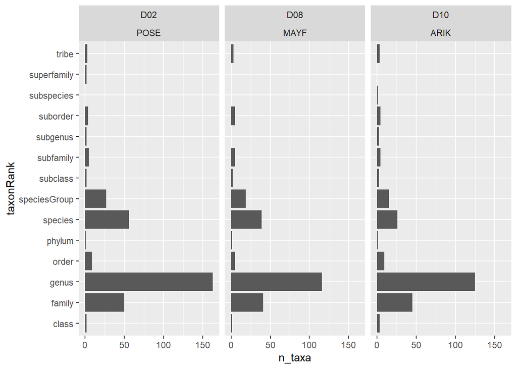

Horizontal bar graph showing the number of taxa for each taxonomic rank at the D02:POSE, D08:MAYF, and D10:ARIK sites. Including facet_wrap to the ggplot call creates a seperate plot for each of the faceting arguments, which in this case are domainID and siteID.

```r
# no. taxa by rank by site
table_observation_cleaned %>%
  group_by(domainID, siteID, taxonRank) %>%
  summarize(
    n_taxa = acceptedTaxonID %>%
        unique() %>% length()) %>%
  ggplot(aes(n_taxa, taxonRank)) +
  facet_wrap(~ domainID + siteID) +
  geom_col()
```

```r
# library(scales)
# sum densities by order for each sampleID
table_observation_by_order <-
    table_observation_cleaned %>%
    filter(!is.na(order)) %>%
    group_by(domainID, siteID, year,
             eventID, sampleID, habitatType, order) %>%
    summarize(order_dens = sum(inv_dens, na.rm = TRUE))


# rank occurrence by order
table_observation_by_order %>% head()
```

```
## # A tibble: 6 x 8
## # Groups:   domainID, siteID, year, eventID, sampleID, habitatType [1]
##   domainID siteID  year eventID    sampleID      habitatType order    order_dens
##   <chr>    <chr>  <dbl> <chr>      <chr>         <chr>       <chr>         <dbl>
## 1 D02      POSE    2014 POSE.2014~ POSE.2014072~ riffle      Branchi~      516.
## 2 D02      POSE    2014 POSE.2014~ POSE.2014072~ riffle      Coleopt~      516.
## 3 D02      POSE    2014 POSE.2014~ POSE.2014072~ riffle      Decapoda       86.0
## 4 D02      POSE    2014 POSE.2014~ POSE.2014072~ riffle      Diptera      5419.
## 5 D02      POSE    2014 POSE.2014~ POSE.2014072~ riffle      Ephemer~     5301.
## 6 D02      POSE    2014 POSE.2014~ POSE.2014072~ riffle      Megalop~      387.
```

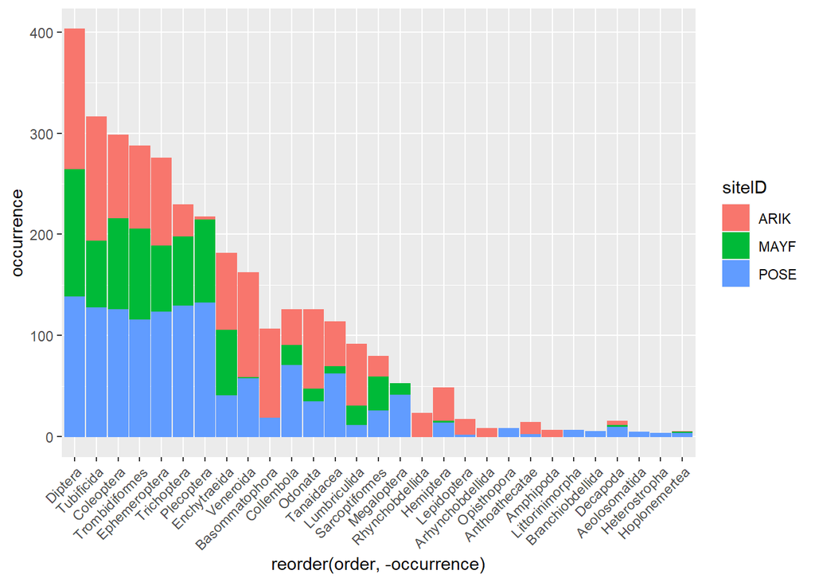

Bar graph of the occurence of each taxonomic order at the D02:POSE, D08:MAYF, and D10:ARIK sites. Occurence data at each site is depicted as stacked bars for each order, where a red bar represents D10:ARIK, a green bar represents D08:MAYF, and a blue bar represents the D02:POSE site. The data has also been reordered to show the greatest to least occuring taxonomic order from left to right.

```r
# stacked rank occurrence plot
table_observation_by_order %>%
  group_by(order, siteID) %>%
  summarize(
    occurrence = (order_dens > 0) %>% sum()) %>%
    ggplot(aes(
        x = reorder(order, -occurrence),
        y = occurrence,
        color = siteID,
        fill = siteID)) +
    geom_col() +
    theme(axis.text.x =
              element_text(angle = 45, hjust = 1))
```

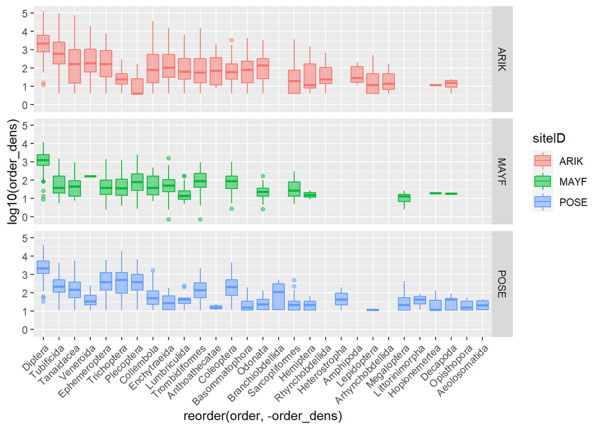

Box plots of the log density of each taxonomic order per site. This graph consists of three box plots, organized vertically in one column, that correspond to log density data for each site. This is achieved through the use of the Facet_grid function in the ggplot call.

```r
# faceted densities plot
table_observation_by_order %>%
  ggplot(aes(
    x = reorder(order, -order_dens),
    y = log10(order_dens),
    color = siteID,
    fill = siteID)) +
  geom_boxplot(alpha = .5) +
  facet_grid(siteID ~ .) +
  theme(axis.text.x =
            element_text(angle = 45, hjust = 1))
```

### Making Data ‘wide’

For the next process, we will need to make our data table in the ‘wide’ format.

```r
# select only site by species density info and remove duplicate records
table_sample_by_taxon_density_long <- table_observation_cleaned %>%
  select(sampleID, acceptedTaxonID, inv_dens) %>%
  distinct() %>%
  filter(!is.na(inv_dens))

# table_sample_by_taxon_density_long %>% nrow()
# table_sample_by_taxon_density_long %>% distinct() %>% nrow()



# pivot to wide format, sum multiple counts per sampleID
table_sample_by_taxon_density_wide <- table_sample_by_taxon_density_long %>%
  tidyr::pivot_wider(id_cols = sampleID,
                     names_from = acceptedTaxonID,
                     values_from = inv_dens,
                     values_fill = list(inv_dens = 0),
                     values_fn = list(inv_dens = sum)) %>%
  column_to_rownames(var = "sampleID")

# check col and row sums -- mins should all be > 0
colSums(table_sample_by_taxon_density_wide) %>% min()
```

```
## [1] 12
```

```r
rowSums(table_sample_by_taxon_density_wide) %>% min()
```

```
## [1] 25.55004
```

## Multiscale Biodiversity

Reference: Jost, L. 2007. Partitioning diversity into independent alpha and beta components. Ecology 88:2427–2439. https://doi.org/10.1890/06-1736.1.

These metrics are based on Robert Whittaker’s multiplicative diversity where * gamma is regional biodiversity * alpha is local biodiversity (e.g., the mean diversity at a patch) * and beta diversity is a measure of among-patch variability in community composition.

Beta could be interpreted as the number of “distinct” communities present within the region.

The relationship among alpha, beta, and gamma diversity is: **beta = gamma / alpha**

The influence of relative abundances over the calculation of alpha, beta, and gamma diversity metrics is determined by the coefficient q. The coefficient “q” determines the “order” of the diversity metric, where q = 0 provides diversity measures based on richness, and higher orders of q give more weight to taxa that have higher abundances in the data. Order q = 1 is related to Shannon diveristy metrics, and order q = 2 is related to Simpson diversity metrics.

#### Alpha diversity is average local richness.

Order q = 0 alpha diversity calculated for our dataset returns a mean local richness (i.e., species counts) of ~30 taxa per sample across the entire data set.

```r
# Here we use vegan::renyi to calculate Hill numbers
# If hill = FALSE, the function returns an entropy
# If hill = TRUE, the function returns the exponentiated
# entropy. In other words:
# exp(renyi entropy) = Hill number = "species equivalent"

# Note that for this function, the "scales" argument
# determines the order of q used in the calculation

table_sample_by_taxon_density_wide %>%
  vegan::renyi(scales = 0, hill = TRUE) %>%
  mean()
```

```
## [1] 30.18859
```

#### Comparing alpha diversity calculated using different orders:

Order q = 1 alpha diversity returns mean number of “species equivalents” per sample in the data set. This approach incorporates evenness because when abundances are more even across taxa, taxa are weighted more equally toward counting as a “species equivalent”. For example, if you have a sample with 100 individuals, spread across 10 species, and each species is represented by 10 individuals, the number of order q = 1 species equivalents will equal the richness (10).

Alternatively, if 90 of the 100 individuals in the sample are one species, and the other 10 individuals are spread across the other 9 species, there will only be 1.72 order q = 1 species equivalents, whereas, there are still 10 species in the sample.

```r
# even distribution, orders q = 0 and q = 1 for 10 taxa
vegan::renyi(
  c(spp.a = 10, spp.b = 10, spp.c = 10,
    spp.d = 10, spp.e = 10, spp.f = 10,
    spp.g = 10, spp.h = 10, spp.i = 10,
    spp.j = 10),
  hill = TRUE,
  scales = c(0, 1))
```

```
##  0  1
## 10 10
## attr(,"class")
## [1] "renyi"   "numeric"
```

```r
# uneven distribution, orders q = 0 and q = 1 for 10 taxa
vegan::renyi(
  c(spp.a = 90, spp.b = 2, spp.c = 1,
    spp.d = 1, spp.e = 1, spp.f = 1,
    spp.g = 1, spp.h = 1, spp.i = 1,
    spp.j = 1),
  hill = TRUE,
  scales = c(0, 1))
```

```
##         0         1
## 10.000000  1.718546
## attr(,"class")
## [1] "renyi"   "numeric"
```

## Comparing orders of q for NEON data

Let’s compare the different orders q = 0, 1, and 2 measures of alpha diversity across the samples collected from ARIK, POSE, and MAYF.

```r
# Nest data by siteID
data_nested_by_siteID <- table_sample_by_taxon_density_wide %>%
  tibble::rownames_to_column("sampleID") %>%
  left_join(table_sample_info %>%
                select(sampleID, siteID)) %>%
  tibble::column_to_rownames("sampleID") %>%
  nest(data = -siteID)

data_nested_by_siteID$data[[1]] %>%
  vegan::renyi(scales = 0, hill = TRUE) %>%
  mean()
```

```
## [1] 25.22302
```

```r
# apply the calculation by site for alpha diversity
# for each order of q
data_nested_by_siteID %>% mutate(
  alpha_q0 = purrr::map_dbl(
    .x = data,
    .f = ~ vegan::renyi(x = .,
                        hill = TRUE,
                        scales = 0) %>% mean()),
  alpha_q1 = purrr::map_dbl(
    .x = data,
    .f = ~ vegan::renyi(x = .,
                        hill = TRUE,
                        scales = 1) %>% mean()),
  alpha_q2 = purrr::map_dbl(
    .x = data,
    .f = ~ vegan::renyi(x = .,
                        hill = TRUE,
                        scales = 2) %>% mean())
  )
```

```
## # A tibble: 3 x 5
##   siteID data                 alpha_q0 alpha_q1 alpha_q2
##   <chr>  <list>                  <dbl>    <dbl>    <dbl>
## 1 ARIK   <tibble [139 x 450]>     25.2     10.5     6.70
## 2 MAYF   <tibble [126 x 450]>     22.9     12.2     8.30
## 3 POSE   <tibble [138 x 450]>     41.8     20.4    12.8
```

```r
# Note that POSE has the highest mean alpha diversity



# To calculate gamma diversity at the site scale,
# calculate the column means and then calculate
# the renyi entropy and Hill number
# Here we are only calcuating order
# q = 0 gamma diversity
data_nested_by_siteID %>% mutate(
  gamma_q0 = purrr::map_dbl(
    .x = data,
    .f = ~ vegan::renyi(x = colMeans(.),
                        hill = TRUE,
                        scales = 0)))
```

```
## # A tibble: 3 x 3
##   siteID data                 gamma_q0
##   <chr>  <list>                  <dbl>
## 1 ARIK   <tibble [139 x 450]>     240.
## 2 MAYF   <tibble [126 x 450]>     237.
## 3 POSE   <tibble [138 x 450]>     326
```

```r
# Note that POSE has the highest gamma diversity



# Now calculate alpha, beta, and gamma using orders 0 and 1
# for each siteID
diversity_partitioning_results <-
  data_nested_by_siteID %>%
  mutate(
    n_samples = purrr::map_int(data, ~ nrow(.)),
    alpha_q0 = purrr::map_dbl(
      .x = data,
      .f = ~ vegan::renyi(x = .,
                          hill = TRUE,
                          scales = 0) %>% mean()),
    alpha_q1 = purrr::map_dbl(
      .x = data,
      .f = ~ vegan::renyi(x = .,
                          hill = TRUE,
                          scales = 1) %>% mean()),
    gamma_q0 = purrr::map_dbl(
      .x = data,
      .f = ~ vegan::renyi(x = colMeans(.),
                          hill = TRUE,
                          scales = 0)),
    gamma_q1 = purrr::map_dbl(
      .x = data,
      .f = ~ vegan::renyi(x = colMeans(.),
                          hill = TRUE,
                          scales = 1)),
    beta_q0 = gamma_q0 / alpha_q0,
    beta_q1 = gamma_q1 / alpha_q1)


diversity_partitioning_results %>%
  select(-data) %>% as.data.frame() %>% print()
```

```
##   siteID n_samples alpha_q0 alpha_q1 gamma_q0 gamma_q1   beta_q0  beta_q1
## 1   ARIK       139 25.22302 10.48685      240 35.45153  9.515117 3.380569
## 2   MAYF       126 22.90476 12.24765      237 64.27611 10.347193 5.248036
## 3   POSE       138 41.84058 20.44035      326 98.91670  7.791479 4.839287
```

## Using NMDS to ordinate samples

Finally, we will use Nonmetric Multidimensional Scaling (NMDS) to ordinate samples as shown below:

```r
# create ordination using NMDS
my_nmds_result <- table_sample_by_taxon_density_wide %>% vegan::metaMDS()
```

```
## Square root transformation
## Wisconsin double standardization
## *** No convergence -- monoMDS stopping criteria:
##     19: stress ratio > sratmax
##      1: scale factor of the gradient < sfgrmin
```

```r
# plot stress
my_nmds_result$stress
```

```
## [1] 0.2283171
```

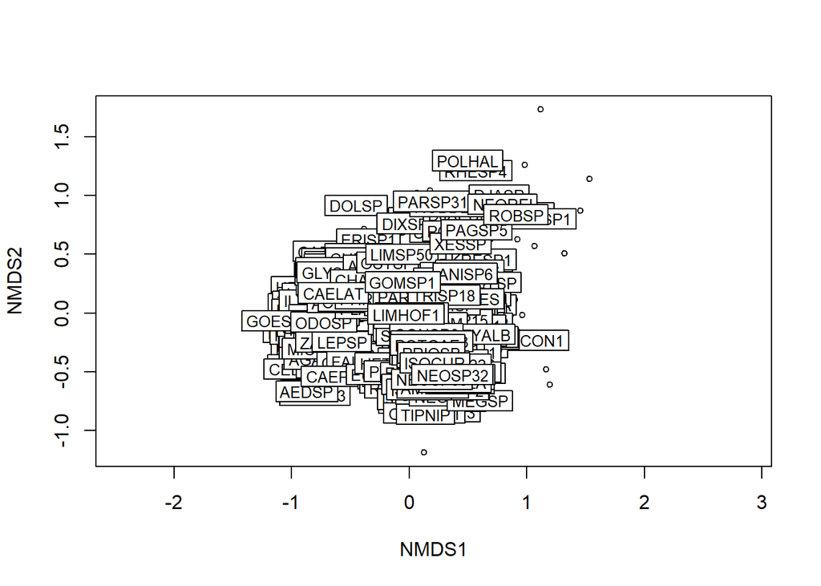

```r
p1 <- vegan::ordiplot(my_nmds_result)
vegan::ordilabel(p1, "species")
```

```r
# merge NMDS scores with sampleID information for plotting
nmds_scores <- my_nmds_result %>% vegan::scores() %>%
  as.data.frame() %>%
  tibble::rownames_to_column("sampleID") %>%
  left_join(table_sample_info)


# # How I determined the outlier(s)
nmds_scores %>% arrange(desc(NMDS1)) %>% head()
```

```
##               sampleID    NMDS1      NMDS2 domainID siteID  namedLocation
## 1 MAYF.20190311.CORE.2 1.532098  1.1396497      D08   MAYF MAYF.AOS.reach
## 2 MAYF.20190311.CORE.1 1.455921  0.8696892      D08   MAYF MAYF.AOS.reach
## 3 MAYF.20180726.CORE.2 1.322213  0.5091943      D08   MAYF MAYF.AOS.reach
## 4 MAYF.20180326.CORE.3 1.193394 -0.6080196      D08   MAYF MAYF.AOS.reach
## 5 MAYF.20150324.SNAG.3 1.161930 -0.4815276      D08   MAYF MAYF.AOS.reach
## 6 MAYF.20170314.CORE.1 1.116985  1.7303061      D08   MAYF MAYF.AOS.reach
##           collectDate       eventID year habitatType samplerType benthicArea
## 1 2019-03-11 15:00:00 MAYF.20190311 2019         run        core       0.006
## 2 2019-03-11 15:00:00 MAYF.20190311 2019         run        core       0.006
## 3 2018-07-26 14:17:00 MAYF.20180726 2018         run        core       0.006
## 4 2018-03-26 14:50:00 MAYF.20180326 2018         run        core       0.006
## 5 2015-03-24 17:15:00 MAYF.20150324 2015         run        snag       0.076
## 6 2017-03-14 14:11:00 MAYF.20170314 2017         run        core       0.006
##            inv_dens_unit
## 1 count per square meter
## 2 count per square meter
## 3 count per square meter
## 4 count per square meter
## 5 count per square meter
## 6 count per square meter
```

```r
nmds_scores %>% arrange(desc(NMDS1)) %>% tail()
```

```
##                    sampleID      NMDS1       NMDS2 domainID siteID
## 398 ARIK.20160919.KICKNET.5 -0.8354417 -0.21059401      D10   ARIK
## 399 ARIK.20160919.KICKNET.1 -0.8434792  0.32082083      D10   ARIK
## 400    ARIK.20150714.CORE.3 -0.8612034  0.03366138      D10   ARIK
## 401    ARIK.20150714.CORE.2 -1.0132855  0.08137423      D10   ARIK
## 402 ARIK.20160919.KICKNET.4 -1.0837740 -0.07898304      D10   ARIK
## 403    ARIK.20160331.CORE.3 -1.1163634 -0.44546655      D10   ARIK
##      namedLocation         collectDate       eventID year habitatType
## 398 ARIK.AOS.reach 2016-09-19 22:06:00 ARIK.20160919 2016         run
## 399 ARIK.AOS.reach 2016-09-19 22:06:00 ARIK.20160919 2016         run
## 400 ARIK.AOS.reach 2015-07-14 14:55:00 ARIK.20150714 2015        pool
## 401 ARIK.AOS.reach 2015-07-14 14:55:00 ARIK.20150714 2015        pool
## 402 ARIK.AOS.reach 2016-09-19 22:06:00 ARIK.20160919 2016         run
## 403 ARIK.AOS.reach 2016-03-31 15:41:00 ARIK.20160331 2016        pool
##         samplerType benthicArea          inv_dens_unit
## 398 modifiedKicknet       0.250 count per square meter
## 399 modifiedKicknet       0.250 count per square meter
## 400            core       0.006 count per square meter
## 401            core       0.006 count per square meter
## 402 modifiedKicknet       0.250 count per square meter
## 403            core       0.006 count per square meter
```

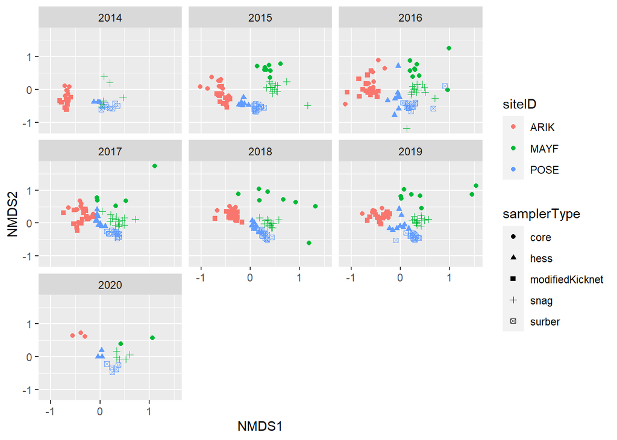

Ordination plots of community composition faceted by year. These plots were acheived by merging NMDS scores with sampleID information in order to plot samples by sampler type(shape) and siteID(color).

```r
# Plot samples in community composition space by year
nmds_scores %>%
  ggplot(aes(NMDS1, NMDS2, color = siteID,
             shape = samplerType)) +
  geom_point() +
  facet_wrap(~ as.factor(year))
```

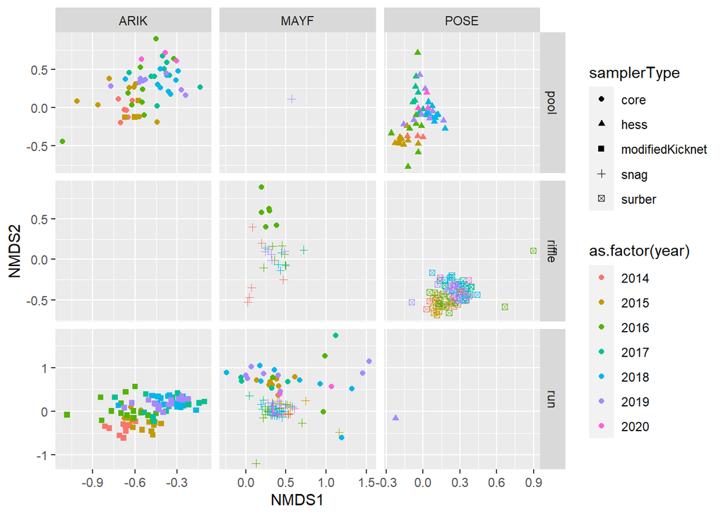

Ordination plots in community composition space faceted by siteID and habitat type. Points are colored to represent different years, as well as different shapes for sampler type.

```r
# Plot samples in community composition space
# facet by siteID and habitat type
# color by year
nmds_scores %>%
  ggplot(aes(NMDS1, NMDS2, color = as.factor(year),
             shape = samplerType)) +
  geom_point() +
  facet_grid(habitatType ~ siteID, scales = "free")
```